# The Analysis of Movie Dataset

### prepared by M. Zahit Gök

- Introduction
- Data Wrangling
- Exploratory Data Analysis
- Conclusions

## Introduction

> In this study, I downloaded the data "tmdb-movies.csv" that contains of the movies info such as cast, name, companies name, revenue, budget etc. my aim is to find some statistics such as number of movies in certain years, total revenues and budget, the relation ships between popularity, vote ratings and revenue. All finding will be entitled as a question in head,ng format.

### importing libraries to be used in investigation

```python
import numpy as np
import pandas as pd
import matplotlib.pyplot as plt
import seaborn as sns
%matplotlib inline
```

## Data Wrangling

> In this section, I removed duplicate rows and cahnged the rows containing 0 value in attributes budget and revenue with a mean value to protect other attributes' information.Moreover, for each question data is arranged for the investigation.

### General Properties

```python
# Load your data and print out a few lines. Perform operations to inspect data
#   types and look for instances of missing or possibly errant data.
moviesDf=pd.read_csv("tmdb-movies.csv")
moviesDf.head(2)
```

|  | id | imdb_id | popularity | budget | revenue | original_title | cast | homepage | director | tagline | ... | overview | runtime | genres | production_companies | release_date | vote_count | vote_average | release_year | budget_adj | revenue_adj |
| --- | --- | --- | --- | --- | --- | --- | --- | --- | --- | --- | --- | --- | --- | --- | --- | --- | --- | --- | --- | --- | --- |
| 0 | 135397 | tt0369610 | 32.985763 | 150000000 | 1513528810 | Jurassic World | Chris Pratt\|Bryce Dallas Howard\|Irrfan Khan\|Vi... | http://www.jurassicworld.com/ | Colin Trevorrow | The park is open. | ... | Twenty-two years after the events of Jurassic ... | 124 | Action\|Adventure\|Science Fiction\|Thriller | Universal Studios\|Amblin Entertainment\|Legenda... | 6/9/15 | 5562 | 6.5 | 2015 | 1.379999e+08 | 1.392446e+09 |
| 1 | 76341 | tt1392190 | 28.419936 | 150000000 | 378436354 | Mad Max: Fury Road | Tom Hardy\|Charlize Theron\|Hugh Keays-Byrne\|Nic... | http://www.madmaxmovie.com/ | George Miller | What a Lovely Day. | ... | An apocalyptic story set in the furthest reach... | 120 | Action\|Adventure\|Science Fiction\|Thriller | Village Roadshow Pictures\|Kennedy Miller Produ... | 5/13/15 | 6185 | 7.1 | 2015 | 1.379999e+08 | 3.481613e+08 |

2 rows × 21 columns

```python
moviesDf.info()
```

```
<class 'pandas.core.frame.DataFrame'>
RangeIndex: 10866 entries, 0 to 10865
Data columns (total 21 columns):
 #   Column                Non-Null Count  Dtype
---  ------                --------------  -----
 0   id                    10866 non-null  int64
 1   imdb_id               10856 non-null  object
 2   popularity            10866 non-null  float64
 3   budget                10866 non-null  int64
 4   revenue               10866 non-null  int64
 5   original_title        10866 non-null  object
 6   cast                  10790 non-null  object
 7   homepage              2936 non-null   object
 8   director              10822 non-null  object
 9   tagline               8042 non-null   object
 10  keywords              9373 non-null   object
 11  overview              10862 non-null  object
 12  runtime               10866 non-null  int64
 13  genres                10843 non-null  object
 14  production_companies  9836 non-null   object
 15  release_date          10866 non-null  object
 16  vote_count            10866 non-null  int64
 17  vote_average          10866 non-null  float64
 18  release_year          10866 non-null  int64
 19  budget_adj            10866 non-null  float64
 20  revenue_adj           10866 non-null  float64
dtypes: float64(4), int64(6), object(11)
memory usage: 1.7+ MB
```

```python
moviesDf.describe()
```

|  | id | popularity | budget | revenue | runtime | vote_count | vote_average | release_year | budget_adj | revenue_adj |
| --- | --- | --- | --- | --- | --- | --- | --- | --- | --- | --- |
| count | 10866.000000 | 10866.000000 | 1.086600e+04 | 1.086600e+04 | 10866.000000 | 10866.000000 | 10866.000000 | 10866.000000 | 1.086600e+04 | 1.086600e+04 |
| mean | 66064.177434 | 0.646441 | 1.462570e+07 | 3.982332e+07 | 102.070863 | 217.389748 | 5.974922 | 2001.322658 | 1.755104e+07 | 5.136436e+07 |
| std | 92130.136561 | 1.000185 | 3.091321e+07 | 1.170035e+08 | 31.381405 | 575.619058 | 0.935142 | 12.812941 | 3.430616e+07 | 1.446325e+08 |
| min | 5.000000 | 0.000065 | 0.000000e+00 | 0.000000e+00 | 0.000000 | 10.000000 | 1.500000 | 1960.000000 | 0.000000e+00 | 0.000000e+00 |
| 25% | 10596.250000 | 0.207583 | 0.000000e+00 | 0.000000e+00 | 90.000000 | 17.000000 | 5.400000 | 1995.000000 | 0.000000e+00 | 0.000000e+00 |
| 50% | 20669.000000 | 0.383856 | 0.000000e+00 | 0.000000e+00 | 99.000000 | 38.000000 | 6.000000 | 2006.000000 | 0.000000e+00 | 0.000000e+00 |
| 75% | 75610.000000 | 0.713817 | 1.500000e+07 | 2.400000e+07 | 111.000000 | 145.750000 | 6.600000 | 2011.000000 | 2.085325e+07 | 3.369710e+07 |
| max | 417859.000000 | 32.985763 | 4.250000e+08 | 2.781506e+09 | 900.000000 | 9767.000000 | 9.200000 | 2015.000000 | 4.250000e+08 | 2.827124e+09 |

## Data Cleaning

in the cell below, I got rid of last two columns budget_adj and revenue_adj. I think for my investigation, revenu and budget will be enough

```python
newMovieDf=moviesDf[["id","imdb_id","popularity","budget","revenue","original_title","cast","director","runtime"
                    ,"genres","production_companies","vote_count","vote_average","release_year"]]
newMovieDf.head(1)
```

|  | id | imdb_id | popularity | budget | revenue | original_title | cast | director | runtime | genres | production_companies | vote_count | vote_average | release_year |
| --- | --- | --- | --- | --- | --- | --- | --- | --- | --- | --- | --- | --- | --- | --- |
| 0 | 135397 | tt0369610 | 32.985763 | 150000000 | 1513528810 | Jurassic World | Chris Pratt\|Bryce Dallas Howard\|Irrfan Khan\|Vi... | Colin Trevorrow | 124 | Action\|Adventure\|Science Fiction\|Thriller | Universal Studios\|Amblin Entertainment\|Legenda... | 5562 | 6.5 | 2015 |

##### removing duplicate rows

```python
display(sum(newMovieDf.duplicated()))

droppedduplicatedNewMovie=newMovieDf.drop_duplicates()
```

```
1
```

```python
sum(droppedduplicatedNewMovie.duplicated())
```

```
0
```

```python
droppedduplicatedNewMovie.isna().any(axis=1).sum()
```

```
1095
```

##### dropping NaN values

```python
droppedduplicatedandNaNNewMovie=droppedduplicatedNewMovie.dropna()
```

```python
droppedduplicatedandNaNNewMovie.isna().any(axis=1).sum()
```

```
0
```

```python
removerevenueZero=droppedduplicatedNewMovie
```

## Exploratory Data Analysis

## what is the top 10 years containing the highest number of movies

```python
result=removerevenueZero.groupby("release_year").size().nlargest(10).reset_index().rename(columns={0:"counts"})

resultTopMovie=removerevenueZero.groupby(["release_year"])["id"].apply(list).reset_index()

result=result.sort_values("counts")

newDataFrameMovieForChartName=pd.DataFrame(columns = ['release_year', 'id',"vote_average","original_title"])

for i in range(int(resultTopMovie.shape[0])):
    listOfid=resultTopMovie.iloc[i]["id"]
    maxVal=0
    for j in range(len(listOfid)):
        row=removerevenueZero[removerevenueZero["id"]==listOfid[j]]
        if maxVal <= row["vote_average"].values[0]:
            maxVal=row["vote_average"].values[0]
            rowTemp=row
    newDataFrameMovieForChartName=newDataFrameMovieForChartName.append({'release_year': rowTemp["release_year"].values[0]
                                         ,"id":rowTemp["id"].values[0]
                                          ,"vote_average":rowTemp["vote_average"].values[0]
                                        ,"original_title":rowTemp["original_title"].values[0]}
                                         , ignore_index=True)



result_all_year=result.set_index('release_year').join(newDataFrameMovieForChartName.set_index('release_year'))
display(result_all_year.head(30))
```

| release_year | counts | id | vote_average | original_title |
| --- | --- | --- | --- | --- |
| 2006 | 408 | 24970 | 8.7 | Pink Floyd: Pulse |
| 2007 | 438 | 13958 | 7.9 | The King of Kong |
| 2010 | 489 | 51299 | 8.8 | Life Cycles |
| 2008 | 496 | 20313 | 8.5 | John Mayer: Where the Light Is Live in Los Ang... |
| 2009 | 533 | 19105 | 8.3 | Iron Maiden: Flight 666 |
| 2011 | 540 | 125336 | 9.2 | The Story of Film: An Odyssey |
| 2012 | 588 | 111349 | 8.3 | One Direction: Up All Night - The Live Tour |
| 2015 | 629 | 224972 | 8.9 | The Mask You Live In |
| 2013 | 659 | 282848 | 8.5 | Doctor Who: The Time of the Doctor |
| 2014 | 700 | 374430 | 8.8 | Black Mirror: White Christmas |

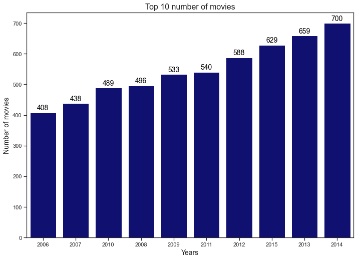

```python
result_all_yearWithResetIndex=result_all_year.reset_index()


sns.set(rc={'figure.figsize':(11.7,8.27)})
sns.set_style("ticks")
ax = sns.barplot(x="release_year", y="counts", data=result_all_yearWithResetIndex, color="navy",
                 order=result_all_yearWithResetIndex["release_year"])

for p in ax.patches:
    ax.annotate(int(p.get_height()),
                   (p.get_x() + p.get_width() / 2., p.get_height()),
                   ha = 'center', va = 'center',
                   xytext = (0, 9),
                   textcoords = 'offset points',
                    rotation=0,color="black",
                    fontsize=14)
ax.set(xlabel='Years', ylabel='number of movies')
ax.set_xlabel("Years",fontsize=14)
ax.set_ylabel("Number of movies",fontsize=14)
ax.axes.set_title("Top 10 number of movies",fontsize=16)
plt.show()
```

## what is the number of movies of each year

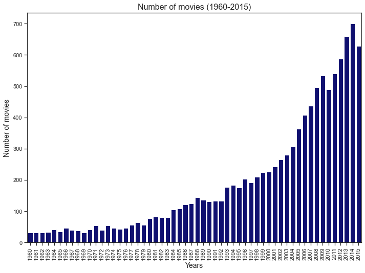

```python
result=removerevenueZero.groupby("release_year").size().reset_index().rename(columns={0:"counts"})

sns.set(rc={'figure.figsize':(11.7,8.27)})
sns.set_style("ticks")
ax = sns.barplot(x="release_year", y="counts", data=result, color="navy",
                 order=result["release_year"])

ax.set(xlabel='Years', ylabel='number of movies')
ax.set_xlabel("Years",fontsize=14)
ax.set_ylabel("Number of movies",fontsize=14)
ax.axes.set_title("Number of movies (1960-2015)",fontsize=16)
ax.set_xticklabels(result["release_year"],rotation=90)
plt.show()
```

in the chart above, the number of movies has been getting increased year by year. there are some fluctions in the trend. However, we can concşude that the general trend is upward.

```python
result_all_yearWithResetIndex=result_all_year.reset_index()
result_all_yearWithResetIndex[["release_year","vote_average","original_title"]]
```

|  | release_year | vote_average | original_title |
| --- | --- | --- | --- |
| 0 | 2006 | 8.7 | Pink Floyd: Pulse |
| 1 | 2007 | 7.9 | The King of Kong |
| 2 | 2010 | 8.8 | Life Cycles |
| 3 | 2008 | 8.5 | John Mayer: Where the Light Is Live in Los Ang... |
| 4 | 2009 | 8.3 | Iron Maiden: Flight 666 |
| 5 | 2011 | 9.2 | The Story of Film: An Odyssey |
| 6 | 2012 | 8.3 | One Direction: Up All Night - The Live Tour |
| 7 | 2015 | 8.9 | The Mask You Live In |
| 8 | 2013 | 8.5 | Doctor Who: The Time of the Doctor |
| 9 | 2014 | 8.8 | Black Mirror: White Christmas |

[figure not shown]

```python
result_all_yearWithResetIndex[["release_year","vote_average","original_title"]]
result_all_yearWithResetIndex["release_year"]=result_all_yearWithResetIndex["release_year"].astype('category')


sns.set(rc={'figure.figsize':(11.7,8.27)})

ax = sns.barplot(y="release_year", x="vote_average", data=result_all_yearWithResetIndex,color="navy")



moviesOfChart=result_all_yearWithResetIndex["original_title"].to_list()
averageOfChart=result_all_yearWithResetIndex["vote_average"].to_list()
indexOfYear=0

for p in ax.patches:
    ax.annotate(str(moviesOfChart[indexOfYear])+" - "+str(averageOfChart[indexOfYear]), xy=(3, p.get_y()+p.get_height()/2),
            xytext=(5, 0), textcoords='offset points', ha="left", va="center",color="white")
    indexOfYear+=1

ax.set_xlabel("Average Rating",fontsize=14)
ax.set_ylabel("Years",fontsize=14)
ax.axes.set_title("Top 10 movies with rating in (2005-2015)",fontsize=16)
plt.show()
```

## Is there any corelation between the attributes revenue, Vote_rating and popularity

```python
removerevenueZero["revenue"].replace(0,removerevenueZero["revenue"].mean(axis=0),inplace=True)
removerevenueZero["budget"].replace(0,removerevenueZero["budget"].mean(axis=0),inplace=True)
```

```python
removerevenueZero["budget"].isnull().sum()
removerevenueZero["revenue"].isna().any().sum()
```

```
0
```

```python
result=removerevenueZero.groupby("release_year").size().nlargest(50).reset_index().rename(columns={0:"counts"})

resultTopMovie=removerevenueZero.groupby(["release_year"])["id"].apply(list).reset_index()

result=result.sort_values("counts")

newDataFrameMovieForChartName=pd.DataFrame(columns = ['release_year', 'id',"vote_average","original_title","revenue","popularity"])

for i in range(int(resultTopMovie.shape[0])):
    listOfid=resultTopMovie.iloc[i]["id"]
    maxVal=0
    for j in range(len(listOfid)):
        row=removerevenueZero[removerevenueZero["id"]==listOfid[j]]
        if maxVal <= row["revenue"].values[0]:
            maxVal=row["revenue"].values[0]
            rowTemp=row
    newDataFrameMovieForChartName=newDataFrameMovieForChartName.append({'release_year': rowTemp["release_year"].values[0]
                                         ,"id":rowTemp["id"].values[0]
                                          ,"vote_average":rowTemp["vote_average"].values[0]
                                        ,"original_title":rowTemp["original_title"].values[0]
                                        ,"revenue":rowTemp["revenue"].values[0],
                                        "popularity":rowTemp["popularity"].values[0]}
                                         , ignore_index=True)



result_all_yearwithrevenue=result.set_index('release_year').join(newDataFrameMovieForChartName.set_index('release_year'))
result_all_yearwithrevenue=result_all_yearwithrevenue.reset_index()
result_all_yearwithrevenue["revenue"]=result_all_yearwithrevenue["revenue"].astype("float64")
display(result_all_yearwithrevenue.info())
```

```
<class 'pandas.core.frame.DataFrame'>
RangeIndex: 50 entries, 0 to 49
Data columns (total 7 columns):
 #   Column          Non-Null Count  Dtype
---  ------          --------------  -----
 0   release_year    50 non-null     int64
 1   counts          50 non-null     int64
 2   id              50 non-null     object
 3   vote_average    50 non-null     float64
 4   original_title  50 non-null     object
 5   revenue         50 non-null     float64
 6   popularity      50 non-null     float64
dtypes: float64(3), int64(2), object(2)
memory usage: 2.9+ KB
```

```
None
```

|  | revenue | popularity | vote_average |
| --- | --- | --- | --- |
| revenue | 1.000000 | 0.630614 | 0.255754 |
| popularity | 0.630614 | 1.000000 | 0.519505 |
| vote_average | 0.255754 | 0.519505 | 1.000000 |

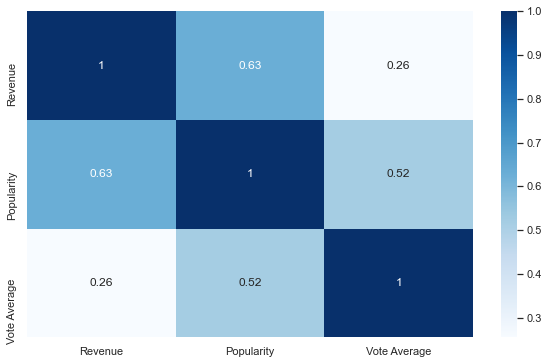

```python
result_all_yearwithrevenueforCorr=result_all_yearwithrevenue[["revenue","popularity","vote_average"]]

plt.figure(figsize=(10,6))

display(result_all_yearwithrevenueforCorr.corr())
sns.heatmap(result_all_yearwithrevenueforCorr.corr(),xticklabels=["Revenue","Popularity","Vote Average"], yticklabels=["Revenue","Popularity","Vote Average"],annot=True,cmap="Blues")
```

in this question, I wanto to find out the corelation between the attributes revenue, vote rating and popularity. My expectation is that reveneu has to have strong corelation tha ttributes mentione before. However, according to chart above, vote average and revenue does not show strong corelation. regarding popularity and revenu, it is stronger bu I was expecting closer to the value 1.

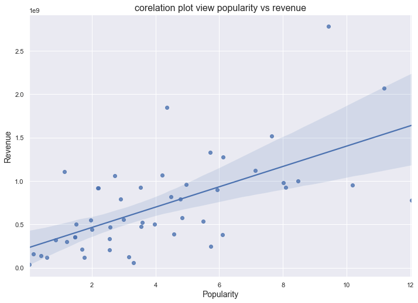

```python
ax=sns.regplot(x="popularity", y="revenue", data=result_all_yearwithrevenueforCorr);
ax.set_xlabel("Popularity",fontsize=14)
ax.set_ylabel("Revenue",fontsize=14)
ax.axes.set_title("corelation plot view popularity vs revenue",fontsize=16)
```

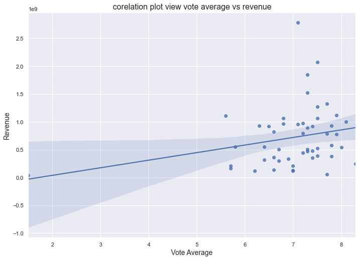

```python
ax=sns.regplot(x="vote_average", y="revenue", data=result_all_yearwithrevenueforCorr);
ax.set_xlabel("Vote Average",fontsize=14)
ax.set_ylabel("Revenue",fontsize=14)
ax.axes.set_title("corelation plot view vote average vs revenue",fontsize=16)
```

By these two plot above, we can also see the connection between the variables

## What is the number of movies of the movie start(Top 10)

adding oscar csv file to find oscar winner in top ten stars

```python
oscarDf=pd.read_csv("oscars.csv")
oscarDf.head(2)
```

|  | oscar_no | oscar_yr | award | name | movie | age | birth_pl | birth_date | birth_mo | birth_d | birth_y |
| --- | --- | --- | --- | --- | --- | --- | --- | --- | --- | --- | --- |
| 0 | 1 | 1929 | Best actress | Janet Gaynor | 7th Heaven | 22 | Pennsylvania | 1906-10-06 | 10 | 6 | 1906 |
| 1 | 2 | 1930 | Best actress | Mary Pickford | Coquette | 37 | Canada | 1892-04-08 | 4 | 8 | 1892 |

```python
oscarDf.info()
```

```
<class 'pandas.core.frame.DataFrame'>
RangeIndex: 184 entries, 0 to 183
Data columns (total 11 columns):
 #   Column      Non-Null Count  Dtype
---  ------      --------------  -----
 0   oscar_no    184 non-null    int64
 1   oscar_yr    184 non-null    int64
 2   award       184 non-null    object
 3   name        184 non-null    object
 4   movie       184 non-null    object
 5   age         184 non-null    int64
 6   birth_pl    184 non-null    object
 7   birth_date  184 non-null    object
 8   birth_mo    184 non-null    int64
 9   birth_d     184 non-null    int64
 10  birth_y     184 non-null    int64
dtypes: int64(6), object(5)
memory usage: 15.9+ KB
```

```python
removerevenueZero = removerevenueZero[removerevenueZero['cast'].notna()]
```

```python
removerevenueZero["cast"].isnull().sum()
```

```
0
```

```python
newMovieWithRowOfCast=removerevenueZero.assign(cast=removerevenueZero.cast.str.split("|")).explode('cast')
newMovieWithRowOfCast.head(2)
```

|  | id | imdb_id | popularity | budget | revenue | original_title | cast | director | runtime | genres | production_companies | vote_count | vote_average | release_year |
| --- | --- | --- | --- | --- | --- | --- | --- | --- | --- | --- | --- | --- | --- | --- |
| 0 | 135397 | tt0369610 | 32.985763 | 150000000.0 | 1.513529e+09 | Jurassic World | Chris Pratt | Colin Trevorrow | 124 | Action\|Adventure\|Science Fiction\|Thriller | Universal Studios\|Amblin Entertainment\|Legenda... | 5562 | 6.5 | 2015 |
| 0 | 135397 | tt0369610 | 32.985763 | 150000000.0 | 1.513529e+09 | Jurassic World | Bryce Dallas Howard | Colin Trevorrow | 124 | Action\|Adventure\|Science Fiction\|Thriller | Universal Studios\|Amblin Entertainment\|Legenda... | 5562 | 6.5 | 2015 |

```python
castNumberOfFilms=newMovieWithRowOfCast.groupby("cast").size().reset_index()
castNumberOfFilms=castNumberOfFilms.rename(columns={0:"numberOfFilms"})
castNumberOfFilms.sort_values(by=['numberOfFilms'], inplace=True,ascending=False)

toptencast=castNumberOfFilms.head(10)
display(toptencast)
```

|  | cast | numberOfFilms |
| --- | --- | --- |
| 15340 | Robert De Niro | 72 |
| 16078 | Samuel L. Jackson | 71 |
| 2508 | Bruce Willis | 62 |
| 13621 | Nicolas Cage | 61 |
| 12583 | Michael Caine | 53 |
| 15519 | Robin Williams | 51 |
| 8957 | John Cusack | 50 |
| 13193 | Morgan Freeman | 49 |
| 8998 | John Goodman | 49 |
| 17249 | Susan Sarandon | 48 |

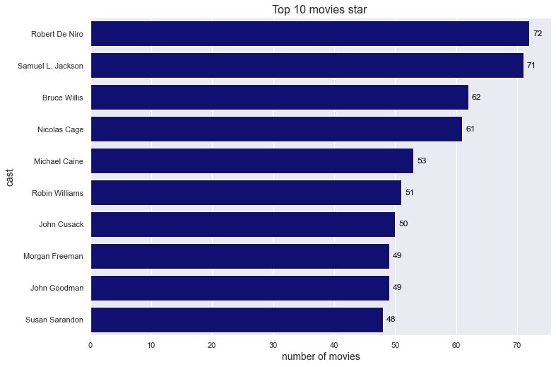

```python
sns.set(rc={'figure.figsize':(11.7,8.27)})

ax = sns.barplot(y="cast", x="numberOfFilms", data=toptencast,color="navy")


for p in ax.patches:
    ax.annotate(int(p.get_width()), xy=(p.get_width(), p.get_y()+p.get_height()/2),
            xytext=(5, 0), textcoords='offset points', ha="left", va="center",color="black")

ax.set_xlabel("number of movies",fontsize=14)
ax.set_ylabel("cast",fontsize=14)
ax.axes.set_title("Top 10 movies star ",fontsize=16)
plt.show()
```

in this question, I want to know the most hardworking actor in the film sector. according to cahrt, Robert De Niro is the most hardworking actor.

finding oscar winners in top 10 stars

```python
newDataframeForOscar=pd.DataFrame()
for i in range(toptencast.shape[0]):
    row=toptencast.iloc[i]
    name=row["cast"]
    tempRow=oscarDf[oscarDf["name"]== str(name)]
    if tempRow.shape[0] > 0:
        newDataframeForOscar=newDataframeForOscar.append(tempRow)

display(newDataframeForOscar)
```

|  | oscar_no | oscar_yr | award | name | movie | age | birth_pl | birth_date | birth_mo | birth_d | birth_y |
| --- | --- | --- | --- | --- | --- | --- | --- | --- | --- | --- | --- |
| 138 | 53 | 1981 | Best actor | Robert De Niro | Raging Bull | 37 | New York | 1943-08-17 | 8 | 17 | 1943 |
| 153 | 68 | 1996 | Best actor | Nicolas Cage | Leaving Las Vegas | 31 | California | 1964-01-07 | 1 | 7 | 1964 |
| 68 | 68 | 1996 | Best actress | Susan Sarandon | Dead Man Walking | 49 | New York | 1946-10-04 | 10 | 4 | 1946 |

## what is the average movie revenue of the movies in which Top 10 movies star played

```python
castRevenueFilms=newMovieWithRowOfCast.groupby("cast").mean().reset_index()
castRevenueFilmsWithTwoColumns=castRevenueFilms[["cast","revenue"]]

castRevenueTopTenJoined=toptencast.set_index('cast').join(castRevenueFilmsWithTwoColumns.set_index('cast'))
display(castRevenueTopTenJoined.head(10))
```

| cast | numberOfFilms | revenue |
| --- | --- | --- |
| Robert De Niro | 72 | 7.783790e+07 |
| Samuel L. Jackson | 71 | 1.123077e+08 |
| Bruce Willis | 62 | 1.148987e+08 |
| Nicolas Cage | 61 | 8.957037e+07 |
| Michael Caine | 53 | 1.213644e+08 |
| Robin Williams | 51 | 1.237430e+08 |
| John Cusack | 50 | 5.962895e+07 |
| Morgan Freeman | 49 | 9.083683e+07 |
| John Goodman | 49 | 9.337326e+07 |
| Susan Sarandon | 48 | 4.167356e+07 |

```python
castRevenueTopTenJoined=castRevenueTopTenJoined.reset_index()
```

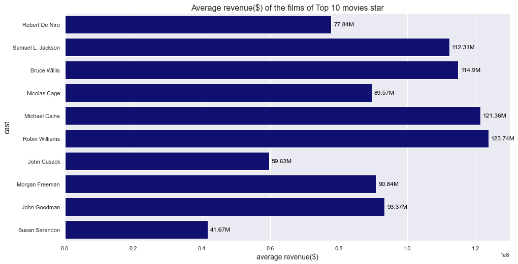

```python
import babel.numbers
from numerize import numerize

sns.set(rc={'figure.figsize':(15.7,8.27)})

ax = sns.barplot(y="cast", x="revenue", data=castRevenueTopTenJoined,color="navy")


for p in ax.patches:
    numTemp=numerize.numerize(int(p.get_width()))
    ax.annotate(numTemp, xy=(p.get_width(), p.get_y()+p.get_height()/2),
            xytext=(5, 0), textcoords='offset points', ha="left", va="center",color="black")


ax.set_xlabel("average revenue($)",fontsize=14)
ax.set_ylabel("cast",fontsize=14)
ax.axes.set_title("Average revenue($) of the films of Top 10 movies star",fontsize=16)
plt.show()
```

## which genres are most popular from year to year(1995-2015)?

```python
newMovieWithRowOfgenres1=removerevenueZero.assign(genres=removerevenueZero.genres.str.split("|")).explode('genres')
newMovieWithRowOfgenres1.head(2)
```

|  | id | imdb_id | popularity | budget | revenue | original_title | cast | director | runtime | genres | production_companies | vote_count | vote_average | release_year |
| --- | --- | --- | --- | --- | --- | --- | --- | --- | --- | --- | --- | --- | --- | --- |
| 0 | 135397 | tt0369610 | 32.985763 | 150000000.0 | 1.513529e+09 | Jurassic World | Chris Pratt\|Bryce Dallas Howard\|Irrfan Khan\|Vi... | Colin Trevorrow | 124 | Action | Universal Studios\|Amblin Entertainment\|Legenda... | 5562 | 6.5 | 2015 |
| 0 | 135397 | tt0369610 | 32.985763 | 150000000.0 | 1.513529e+09 | Jurassic World | Chris Pratt\|Bryce Dallas Howard\|Irrfan Khan\|Vi... | Colin Trevorrow | 124 | Adventure | Universal Studios\|Amblin Entertainment\|Legenda... | 5562 | 6.5 | 2015 |

```python
result=newMovieWithRowOfgenres1.groupby(["release_year","genres"]).size().reset_index().rename(columns={0:"counts"})

topGenreEachYear=pd.DataFrame(columns=["release_year","topGenre","numberOfGenre"])
minVal=result["release_year"].min()
maxVal=result["release_year"].max()+1
for i in range(minVal,maxVal):
    resultSub=result.query(f"release_year == {i}")
    rowTemp=resultSub.loc[resultSub['counts'].idxmax()]
    topGenreEachYear=topGenreEachYear.append({"release_year":rowTemp["release_year"],
                                             "topGenre":rowTemp["genres"],
                                             "numberOfGenre":rowTemp["counts"]},ignore_index=True)

display(topGenreEachYear.head())
```

|  | release_year | topGenre | numberOfGenre |
| --- | --- | --- | --- |
| 0 | 1960 | Drama | 13 |
| 1 | 1961 | Drama | 16 |
| 2 | 1962 | Drama | 21 |
| 3 | 1963 | Comedy | 13 |
| 4 | 1964 | Drama | 20 |

[figure not shown]

```python
topGenreEachYear["numberOfGenre"]=topGenreEachYear["numberOfGenre"].astype('int64')
topGenreEachYeartopten=topGenreEachYear.nlargest(20,"numberOfGenre")
sns.set(rc={'figure.figsize':(11.7,8.27)})
topGenreEachYeartopten["release_year"]=topGenreEachYeartopten["release_year"].astype('category')
ax = sns.barplot(y="release_year", x="numberOfGenre", data=topGenreEachYeartopten,color="navy")


moviesOfChart=topGenreEachYeartopten["topGenre"].to_list()
indexOfYear=0

for p in ax.patches:
    ax.annotate(str(moviesOfChart[indexOfYear]), xy=(8, p.get_y()+p.get_height()/2),
            xytext=(5, 0), textcoords='offset points', ha="left", va="center",color="white")
    indexOfYear+=1

ax.set_xlabel("number of genre",fontsize=14)
ax.set_ylabel("year",fontsize=14)
ax.axes.set_title("top genres in each year(1995-2015)",fontsize=16)
plt.show()
```

in this question, I found out that in many years, the type of films drama were created.

## what is the number of movies of the companies Top 20 company

```python
removerevenueZero=droppedduplicatedNewMovie
```

```python
removerevenueZero["production_companies"].isnull().sum()
```

```
1030
```

```python
removerevenueZero = removerevenueZero[removerevenueZero['production_companies'].notna()]
```

```python
removerevenueZero["production_companies"].isnull().sum()
```

```
0
```

```python
newMovieWithRowOfProduction=removerevenueZero.assign(production_companies=removerevenueZero.production_companies.str.split("|")).explode('production_companies')
newMovieWithRowOfProduction.head(2)
```

|  | id | imdb_id | popularity | budget | revenue | original_title | cast | director | runtime | genres | production_companies | vote_count | vote_average | release_year |
| --- | --- | --- | --- | --- | --- | --- | --- | --- | --- | --- | --- | --- | --- | --- |
| 0 | 135397 | tt0369610 | 32.985763 | 150000000.0 | 1.513529e+09 | Jurassic World | Chris Pratt\|Bryce Dallas Howard\|Irrfan Khan\|Vi... | Colin Trevorrow | 124 | Action\|Adventure\|Science Fiction\|Thriller | Universal Studios | 5562 | 6.5 | 2015 |
| 0 | 135397 | tt0369610 | 32.985763 | 150000000.0 | 1.513529e+09 | Jurassic World | Chris Pratt\|Bryce Dallas Howard\|Irrfan Khan\|Vi... | Colin Trevorrow | 124 | Action\|Adventure\|Science Fiction\|Thriller | Amblin Entertainment | 5562 | 6.5 | 2015 |

```python
newMovieWithRowOfProductionTopTwenty=newMovieWithRowOfProduction.groupby("production_companies").size().reset_index()\
.rename(columns={0:"counts"}).nlargest(20,"counts")
display(newMovieWithRowOfProductionTopTwenty)
```

|  | production_companies | counts |
| --- | --- | --- |
| 7372 | Universal Pictures | 522 |
| 7582 | Warner Bros. | 509 |
| 5303 | Paramount Pictures | 431 |
| 7257 | Twentieth Century Fox Film Corporation | 282 |
| 1605 | Columbia Pictures | 272 |
| 4913 | New Line Cinema | 219 |
| 4558 | Metro-Goldwyn-Mayer (MGM) | 218 |
| 7567 | Walt Disney Pictures | 214 |
| 7167 | Touchstone Pictures | 178 |
| 1606 | Columbia Pictures Corporation | 160 |
| 7202 | TriStar Pictures | 147 |
| 4654 | Miramax Films | 139 |
| 5825 | Relativity Media | 108 |
| 5820 | Regency Enterprises | 95 |
| 1227 | Canal+ | 92 |
| 29 | 20th Century Fox | 88 |
| 2074 | DreamWorks SKG | 88 |
| 7480 | Village Roadshow Pictures | 88 |
| 659 | BBC Films | 87 |
| 1971 | Dimension Films | 82 |

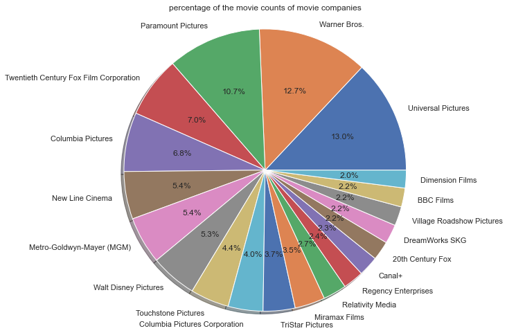

```python
labels =newMovieWithRowOfProductionTopTwenty["production_companies"].to_list()


fig1, ax1 = plt.subplots()
ax1.pie(newMovieWithRowOfProductionTopTwenty["counts"], labels=labels, autopct='%1.1f%%', shadow=True)
ax1.axis('equal')
plt.title("percentage of the movie counts of movie companies")
plt.show()
```

in this question, I found out that the top 3 companies about the number of films are Universal Pictures, Warner Bros. and Paramount Pictures.

## What is the total revenue and budget of the companies

```python
removerevenueZero=droppedduplicatedNewMovie
```

```python
removerevenueZero["revenue"].replace(0,removerevenueZero["revenue"].mean(axis=0),inplace=True)
removerevenueZero["budget"].replace(0,removerevenueZero["budget"].mean(axis=0),inplace=True)
```

[output not shown]

```python
newMovieWithRowOfProductionTopTwentyRevenue=newMovieWithRowOfProduction.groupby("production_companies").sum().reset_index()\
.nlargest(20,"revenue")
#.rename(columns={0:"total"})
display(newMovieWithRowOfProductionTopTwentyRevenue.head())
dataForChartCompanyAndRevenue=newMovieWithRowOfProductionTopTwentyRevenue[["production_companies","budget","revenue"]]
```

|  | production_companies | id | popularity | budget | revenue | runtime | vote_count | vote_average | release_year |
| --- | --- | --- | --- | --- | --- | --- | --- | --- | --- |
| 7582 | Warner Bros. | 13123989 | 590.824364 | 2.220750e+10 | 6.002524e+10 | 58108 | 277663 | 3139.8 | 1015820 |
| 7372 | Universal Pictures | 15019669 | 499.892618 | 1.792869e+10 | 5.355144e+10 | 56684 | 212252 | 3169.7 | 1042027 |
| 5303 | Paramount Pictures | 10610261 | 418.167801 | 1.565287e+10 | 4.584923e+10 | 47186 | 180608 | 2649.9 | 859441 |
| 7257 | Twentieth Century Fox Film Corporation | 7707778 | 345.733103 | 1.143450e+10 | 4.005849e+10 | 30820 | 171731 | 1724.6 | 562372 |
| 7567 | Walt Disney Pictures | 8060686 | 295.744474 | 1.181675e+10 | 3.587719e+10 | 19426 | 134398 | 1321.7 | 428350 |

```python
dataForChartCompanyAndRevenue=newMovieWithRowOfProductionTopTwentyRevenue[["production_companies","budget","revenue"]]
display(dataForChartCompanyAndRevenue.head())
```

|  | production_companies | budget | revenue |
| --- | --- | --- | --- |
| 7582 | Warner Bros. | 2.220750e+10 | 6.002524e+10 |
| 7372 | Universal Pictures | 1.792869e+10 | 5.355144e+10 |
| 5303 | Paramount Pictures | 1.565287e+10 | 4.584923e+10 |
| 7257 | Twentieth Century Fox Film Corporation | 1.143450e+10 | 4.005849e+10 |
| 7567 | Walt Disney Pictures | 1.181675e+10 | 3.587719e+10 |

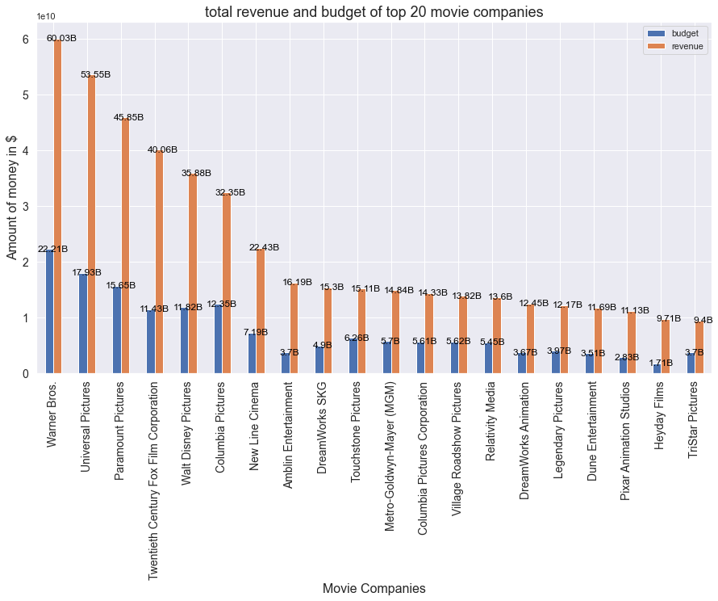

```python
ax=dataForChartCompanyAndRevenue.plot.bar(rot=0,x="production_companies",fontsize=14
                                          ,figsize=(15,8))
for p in ax.patches:
    numTemp=numerize.numerize(int(p.get_height()))
    ax.annotate(numTemp, xy=(p.get_x() + p.get_width() / 2., p.get_height()+2),
            xytext=(5, 0), textcoords='offset points', ha="center", va="center",color="black",rotation=0)

ax.set_xlabel("Movie Companies", fontsize=16)
ax.set_ylabel("Amount of money in $",fontsize=16)
plt.xticks(rotation='vertical')
plt.title("total revenue and budget of top 20 movie companies",fontsize=18)
plt.show()
```

According the chart above, nearly all companies could get total revenue which is equal to almost 3 times total budget.

## Conclusions

In this study, I investigated the movie data containing the info about the movie such as actors, name of movie, revenue and budget etc. I found out some weak corelation between popularity, vote average and revenue. I xpose some statistics about the companies and actors. Moreover, the number of movies and genres of the movies were investigated.